# Tidy Tuesday Orca

Brandon Brenes

2024-11-02

# Description

We will be looking to see if there is a seasonal variation in the encounter number at Haro Strait. To do this we will make a violin plot with season on the x axis and encounters on the y axis. The challenge for me will be to learn how to make seasonal data using their *date* variable. In addition to this, I will also be making a violin plot for the first time and utilize a new theme for rmarkdown and ggplot.

# Libraries

```r
# library #

library(tidyr)
library(dplyr)
library(readr)
library(ggplot2)
library(cowplot)
library(forcats)
library(prettydoc)
library(lubridate)
```

# Load Data

```r
# load data from tidy tuesday orcas #

raw_orcas <-read_csv('https://raw.githubusercontent.com/rfordatascience/tidytuesday/master/data/2024/2024-10-15/orcas.csv')

head(raw_orcas)
```

```
## # A tibble: 6 × 19
##    year date       encounter_sequence encounter_number begin_time end_time
##   <dbl> <date>     <chr>                         <dbl> <time>     <time>
## 1  2024 2024-10-06 1                               100 10:48      12:21
## 2  2024 2024-09-16 1                                96 09:30      10:11
## 3  2024 2024-09-15 21                               95 02:15      05:00
## 4  2024 2024-09-13 2                                94 10:34      12:05
## 5  2024 2024-09-13 1                                93 08:45      09:26
## 6  2024 2024-09-12 2                                92 12:53      03:00
## # ℹ 13 more variables: duration <chr>, vessel <chr>, observers <chr>,
## #   pods_or_ecotype <chr>, ids_encountered <chr>, location <chr>,
## #   begin_latitude <dbl>, begin_longitude <dbl>, end_latitude <dbl>,
## #   end_longitude <dbl>, encounter_summary <chr>, nmfs_permit <chr>, link <chr>
```

# Data manipulation

**Clean up the data:**

Select on the necessary columns, filter data that was collected in Haro Strait and create a season column using the dates (lubridate).

```r
# clean up raw data #

# select out the columns we need (date, year and encounter) and only data in location Haro Strait, manipulate the data give seasons for dates.

clean_orcas <- raw_orcas %>%
  filter(location == "Haro Strait") %>% #only data from Haro Strait
  select(year, date, encounter_number) %>% #select out variables needed
  mutate(
    date = ymd(date),
    season = case_when(#make month within these numbered months equal to this "season"
      month(date) %in% 3:5  ~ "Spring",
      month(date) %in% 6:8  ~ "Summer",
      month(date) %in% 9:11 ~ "Fall",
      TRUE                  ~ "Winter"
    )
  )

head(clean_orcas)
```

```
## # A tibble: 6 × 4
##    year date       encounter_number season
##   <dbl> <date>                <dbl> <chr>
## 1  2024 2024-09-16               96 Fall
## 2  2024 2024-09-15               95 Fall
## 3  2024 2024-07-03               64 Summer
## 4  2024 2024-06-28               62 Summer
## 5  2024 2024-06-26               61 Summer
## 6  2024 2024-06-25               59 Summer
```

**Summary data for plot:**

Find the difference between encounter numbers in each season because the number encounter number restarts every year.

```r
summary_orcas<-clean_orcas %>%
 group_by(year, season) %>% #group by year and season
  summarize(#subtract the min from the max for ecounter number for that years seasons.
    min_encounter = min(encounter_number, na.rm = TRUE),
    max_encounter = max(encounter_number, na.rm = TRUE),
    encounter_diff = max_encounter - min_encounter
  ) %>%
  ungroup() %>% #ungroup just for safety reasons
  drop_na() #drop na from dataset

head(summary_orcas)
```

```
## # A tibble: 6 × 5
##    year season min_encounter max_encounter encounter_diff
##   <dbl> <chr>          <dbl>         <dbl>          <dbl>
## 1  2017 Fall              74            96             22
## 2  2017 Spring            22            40             18
## 3  2017 Summer            45            65             20
## 4  2017 Winter             2           111            109
## 5  2018 Fall              75           102             27
## 6  2018 Spring            15            34             19
```

# Plot

Now we use the encounter diff as the number of encounters in that season and create a violin plot showing the seasonal variation in encounters:

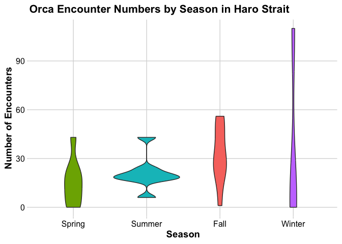

```r
# violin plot of number of occurrences by season

orca_plot<- ggplot(summary_orcas, aes(x = fct_relevel(season, "Spring", "Summer", "Fall", "Winter"), y = encounter_diff)) +#use fct_relevel so it puts seasons in order
  geom_violin(aes(fill = season)) + #violin plot
  labs(
    x = "Season",
    y =  "Number of Encounters",
    title = "Orca Encounter Numbers by Season in Haro Strait",
    fill = "Season"
  ) +
  theme_minimal_grid() + #new theme!
  theme(
    legend.position = "none",                # removes the legend
    axis.title = element_text(face = "bold") # bold axis titles
  )


library(cowplot)

orca_plot <- ggplot(summary_orcas, aes(x = fct_relevel(season, "Spring", "Summer", "Fall", "Winter"), y = encounter_diff)) +
  geom_violin(aes(fill = season)) +
  labs(
    x = "Season",
    y =  "Number of Encounters",
    title = "Orca Encounter Numbers by Season in Haro Strait",
    fill = "Season"
  ) +
  theme_minimal_grid() +  # Start with theme_minimal_grid from cowplot
  theme(
    panel.background = element_rect(fill = "white", color = NA),  # White background
    plot.background = element_rect(fill = "white", color = NA),   # White background around plot
    legend.position = "none",                                     # Removes the legend
    axis.title = element_text(face = "bold")                      # Bold axis titles
  )

orca_plot
```

# What did I learn?

In this week’s *tidy_tuesday*, I learned how to make seasons out of dates - a very useful tool when looking at time-series data. I also learned how to make a violin plot, which perfectly displayed the spread in values for these encounters over time. Lastly, I used different themes for the plot and the rmarkdown html file, both of which had to be installed.